# Developing an AI application

Going forward, AI algorithms will be incorporated into more and more everyday applications. For example, you might want to include an image classifier in a smart phone app. To do this, you'd use a deep learning model trained on hundreds of thousands of images as part of the overall application architecture. A large part of software development in the future will be using these types of models as common parts of applications.

In this project, you'll train an image classifier to recognize different species of flowers. You can imagine using something like this in a phone app that tells you the name of the flower your camera is looking at. In practice you'd train this classifier, then export it for use in your application. We'll be using [this dataset](http://www.robots.ox.ac.uk/~vgg/data/flowers/102/index.html) of 102 flower categories, you can see a few examples below.

[figure not shown]

The project is broken down into multiple steps:

- Load and preprocess the image dataset
- Train the image classifier on your dataset
- Use the trained classifier to predict image content

We'll lead you through each part which you'll implement in Python.

When you've completed this project, you'll have an application that can be trained on any set of labeled images. Here your network will be learning about flowers and end up as a command line application. But, what you do with your new skills depends on your imagination and effort in building a dataset. For example, imagine an app where you take a picture of a car, it tells you what the make and model is, then looks up information about it. Go build your own dataset and make something new.

First up is importing the packages you'll need. It's good practice to keep all the imports at the beginning of your code. As you work through this notebook and find you need to import a package, make sure to add the import up here.

```python
import torch
from torch import nn
from torchvision import datasets, transforms, models

import json
import pandas as pd
import numpy as np
import re
import matplotlib.pyplot as plt
%matplotlib inline

import PIL

from itertools import product
from collections import OrderedDict
```

# Load the data

Here you'll use `torchvision` to load the data ([documentation](http://pytorch.org/docs/0.3.0/torchvision/index.html)). The data should be included alongside this notebook, otherwise you can [download it here](https://s3.amazonaws.com/content.udacity-data.com/nd089/flower_data.tar.gz). The dataset is split into three parts, training, validation, and testing. For the training, you'll want to apply transformations such as random scaling, cropping, and flipping. This will help the network generalize leading to better performance. You'll also need to make sure the input data is resized to 224x224 pixels as required by the pre-trained networks.

The validation and testing sets are used to measure the model's performance on data it hasn't seen yet. For this you don't want any scaling or rotation transformations, but you'll need to resize then crop the images to the appropriate size.

The pre-trained networks you'll use were trained on the ImageNet dataset where each color channel was normalized separately. For all three sets you'll need to normalize the means and standard deviations of the images to what the network expects. For the means, it's `[0.485, 0.456, 0.406]` and for the standard deviations `[0.229, 0.224, 0.225]`, calculated from the ImageNet images. These values will shift each color channel to be centered at 0 and range from -1 to 1.

```python
data_dir = 'flowers'
train_dir = data_dir + '/train'
valid_dir = data_dir + '/valid'
test_dir = data_dir + '/test'
```

```python
# TODO: Define your transforms for the training, validation, and testing sets
data_transforms = {
    'train': transforms.Compose([
        transforms.RandomRotation(30),
        transforms.RandomResizedCrop(224),
        transforms.RandomHorizontalFlip(),
        transforms.ToTensor(),
        transforms.Normalize([0.485, 0.456, 0.406],
                             [0.229, 0.224, 0.225])
    ]),
    'test': transforms.Compose([
        transforms.Resize(224),
        transforms.CenterCrop(224),
        transforms.ToTensor(),
        transforms.Normalize([0.485, 0.456, 0.406],
                             [0.229, 0.224, 0.225])
    ]),
    'valid': transforms.Compose([
        transforms.Resize(224),
        transforms.CenterCrop(224),
        transforms.ToTensor(),
        transforms.Normalize([0.485, 0.456, 0.406],
                             [0.229, 0.224, 0.225])
    ])
}

# TODO: Load the datasets with ImageFolder
image_datasets = {
    'train': datasets.ImageFolder(train_dir, transform=data_transforms['train']),
    'test': datasets.ImageFolder(test_dir, transform=data_transforms['test']),
    'valid': datasets.ImageFolder(valid_dir, transform=data_transforms['valid']),
}

# TODO: Using the image datasets and the trainforms, define the dataloaders
dataloaders = {
    'train': torch.utils.data.DataLoader(image_datasets['train'], batch_size=64, shuffle=True),
    'test': torch.utils.data.DataLoader(image_datasets['test'], batch_size=32),
    'valid': torch.utils.data.DataLoader(image_datasets['valid'], batch_size=8)
}
```

### Label mapping

You'll also need to load in a mapping from category label to category name. You can find this in the file `cat_to_name.json`. It's a JSON object which you can read in with the [`json` module](https://docs.python.org/2/library/json.html). This will give you a dictionary mapping the integer encoded categories to the actual names of the flowers.

```python
with open('cat_to_name.json', 'r') as f:
    cat_to_name = json.load(f)
```

# Building and training the classifier

Now that the data is ready, it's time to build and train the classifier. As usual, you should use one of the pretrained models from `torchvision.models` to get the image features. Build and train a new feed-forward classifier using those features.

We're going to leave this part up to you. If you want to talk through it with someone, chat with your fellow students! You can also ask questions on the forums or join the instructors in office hours.

Refer to [the rubric](https://review.udacity.com/#!/rubrics/1663/view) for guidance on successfully completing this section. Things you'll need to do:

- Load a [pre-trained network](http://pytorch.org/docs/master/torchvision/models.html) (If you need a starting point, the VGG networks work great and are straightforward to use)
- Define a new, untrained feed-forward network as a classifier, using ReLU activations and dropout
- Train the classifier layers using backpropagation using the pre-trained network to get the features
- Track the loss and accuracy on the validation set to determine the best hyperparameters

We've left a cell open for you below, but use as many as you need. Our advice is to break the problem up into smaller parts you can run separately. Check that each part is doing what you expect, then move on to the next. You'll likely find that as you work through each part, you'll need to go back and modify your previous code. This is totally normal!

When training make sure you're updating only the weights of the feed-forward network. You should be able to get the validation accuracy above 70% if you build everything right. Make sure to try different hyperparameters (learning rate, units in the classifier, epochs, etc) to find the best model. Save those hyperparameters to use as default values in the next part of the project.

```python
# TODO: Build and train your network

def create_model(hidden_size=4096, p_dropout=0.5):

    model = models.vgg11(pretrained=True)

    for param in model.features.parameters():
        param.requires_grad_(False)

    classifier = nn.Sequential(OrderedDict([
        ('fc1',nn.Linear(in_features=25088, out_features=hidden_size, bias=True)),
        ('ReLU_1', nn.ReLU()),
        ('Dropout', nn.Dropout(p=p_dropout)),
        ('fc2', nn.Linear(in_features=hidden_size, out_features=102, bias=True)),
        ('LogSoftmax', nn.LogSoftmax(dim=1))
    ]
    ))

    model.add_module('classifier', classifier)

    return model
```

```python
criterion = nn.NLLLoss()

def make_optimizer(model, lr=0.001):
    return torch.optim.Adam(model.classifier.parameters(), lr=lr)
```

```python
def train_model(model, optimizer, print_every=5, yield_every=10, epochs=3):

    model.to('cuda')
    model.train()

    batches_trained = 0
    for e in range(epochs):
        running_loss = 0
        for i, (images, labels) in enumerate(dataloaders['train']):
            images, labels = images.to('cuda'), labels.to('cuda')
            model.train()
            optimizer.zero_grad()

            outputs = model.forward(images)
            loss = criterion(outputs, labels)
            loss.backward()
            optimizer.step()

            running_loss += loss
            batches_trained += 1

            if (i+1)%print_every==0:
                print('Epoch {}/{}, running training loss on training batches {} to {}: {}'.format(
                    e+1, epochs, i-4, i+1, running_loss/print_every))
                running_loss = 0

            if batches_trained%yield_every == 0:
                yield model, e+1, batches_trained

        yield model, e+1, batches_trained
```

```python
def create_train_return_model(hidden_size, p_dropout, learning_rate, epochs):

    model = create_model(hidden_size, p_dropout)
    model.to('cuda')
    model.train()

    optimizer = make_optimizer(model, learning_rate)

    for e in range(epochs):
        for i, (images, labels) in enumerate(dataloaders['train']):
            images, labels = images.to('cuda'), labels.to('cuda')
            model.train()
            optimizer.zero_grad()

            outputs = model.forward(images)
            loss = criterion(outputs, labels)
            loss.backward()
            optimizer.step()

    return model
```

## Testing your network

It's good practice to test your trained network on test data, images the network has never seen either in training or validation. This will give you a good estimate for the model's performance on completely new images. Run the test images through the network and measure the accuracy, the same way you did validation. You should be able to reach around 70% accuracy on the test set if the model has been trained well.

```python
def initiate_accuracy_df():
    df = pd.DataFrame(
        columns=pd.MultiIndex.from_product(
            [hidden_sizes, dropout_probs, learning_rates],
            names=['Hidden size', 'Dropout P', 'Learning rate']),
        index=pd.MultiIndex(
            names=['Epoch', 'batches'],
            levels=[[], []],
            labels=[[], []]
        )
    )
    return df
```

```python
# TODO: Do validation on the test set

# Hyperparameters to test
learning_rates = [0.001, 0.01]
hidden_sizes = [1024, 4096]
dropout_probs = [0.2, 0.5]
max_epochs = 3

evaluate_every = 20

test_accuracies = initiate_accuracy_df()
validation_accuracies = initiate_accuracy_df()

for hidden_size, p_dropout, lr in product(hidden_sizes,
                                          dropout_probs,
                                          learning_rates):

    model = create_model(hidden_size, p_dropout)
    optimizer = make_optimizer(model, lr)

    for (trained_model, e, batches_trained) in train_model(
        model, optimizer, yield_every=evaluate_every, epochs=max_epochs):

        trained_model.eval()

        correct = 0
        total = 0

        for images, labels in dataloaders['test']:
            images, labels = images.to('cuda'), labels.to('cuda')

            with torch.no_grad():
                outputs = trained_model(images)
                predicted = outputs.max(dim=1)[1]
                correct += (predicted==labels).sum().item()
                total += (predicted==labels).size()[0]

        test_accuracies.loc[(e, batches_trained), (hidden_size, p_dropout, lr)] = correct/total
        print('Test accuracy after {} training batches : {}'.format(batches_trained, correct/total))

        correct = 0
        total = 0
        loss = 0

        for i, (images, labels) in enumerate(dataloaders['valid']):
            images, labels = images.to('cuda'), labels.to('cuda')

            with torch.no_grad():
                outputs = trained_model(images)
                predicted = outputs.max(dim=1)[1]
                correct += (predicted==labels).sum().item()
                total += (predicted==labels).size()[0]
                loss += criterion(outputs, labels)

        validation_accuracies.loc[(e, batches_trained), (hidden_size, p_dropout, lr)] = correct/total
        print('Validation loss after {} training batches : {}'.format(batches_trained, loss/(i+1)))
        print('Validation accuracy after {} training batches : {}'.format(batches_trained, correct/total))
```

```
Test accuracy after 20 training batches : 0.42857142857142855
Validation loss after 20 training batches : 2.592862367630005
Validation accuracy after 20 training batches : 0.44621026894865523
Test accuracy after 40 training batches : 0.6153846153846154
Validation loss after 40 training batches : 1.4878156185150146
Validation accuracy after 40 training batches : 0.6149144254278729
Test accuracy after 60 training batches : 0.706959706959707
Validation loss after 60 training batches : 1.0304679870605469
Validation accuracy after 60 training batches : 0.7127139364303179
Test accuracy after 80 training batches : 0.7533577533577533
Validation loss after 80 training batches : 0.8618629574775696
Validation accuracy after 80 training batches : 0.7799511002444988
Test accuracy after 100 training batches : 0.7777777777777778
Validation loss after 100 training batches : 0.7295324802398682
Validation accuracy after 100 training batches : 0.8141809290953546
Test accuracy after 103 training batches : 0.778998778998779
Validation loss after 103 training batches : 0.718707799911499
Validation accuracy after 103 training batches : 0.7909535452322738
Test accuracy after 120 training batches : 0.7814407814407814
Validation loss after 120 training batches : 0.7357386946678162
Validation accuracy after 120 training batches : 0.7970660146699267
Test accuracy after 140 training batches : 0.7851037851037851
Validation loss after 140 training batches : 0.6715192198753357
Validation accuracy after 140 training batches : 0.8227383863080685
Test accuracy after 160 training batches : 0.8192918192918193
Validation loss after 160 training batches : 0.5697746276855469
Validation accuracy after 160 training batches : 0.8606356968215159
Test accuracy after 180 training batches : 0.8351648351648352
Validation loss after 180 training batches : 0.6011514067649841
Validation accuracy after 180 training batches : 0.8398533007334963
Test accuracy after 200 training batches : 0.8253968253968254
Validation loss after 200 training batches : 0.5918784737586975
Validation accuracy after 200 training batches : 0.8508557457212714
Test accuracy after 206 training batches : 0.8376068376068376
Validation loss after 206 training batches : 0.5340988636016846
Validation accuracy after 206 training batches : 0.8581907090464548
Test accuracy after 220 training batches : 0.8412698412698413
Validation loss after 220 training batches : 0.5364022254943848
Validation accuracy after 220 training batches : 0.8557457212713936
Test accuracy after 240 training batches : 0.8534798534798534
```

[output cut: 377 more lines]

```
Test accuracy after 240 training batches : 0.1221001221001221
Validation loss after 240 training batches : 4.220216751098633
Validation accuracy after 240 training batches : 0.11858190709046455
Test accuracy after 260 training batches : 0.11233211233211234
Validation loss after 260 training batches : 4.2660722732543945
Validation accuracy after 260 training batches : 0.1039119804400978
Test accuracy after 280 training batches : 0.09157509157509157
Validation loss after 280 training batches : 4.244589805603027
Validation accuracy after 280 training batches : 0.09290953545232274
Test accuracy after 300 training batches : 0.09768009768009768
Validation loss after 300 training batches : 4.301209926605225
Validation accuracy after 300 training batches : 0.09046454767726161
Test accuracy after 309 training batches : 0.0989010989010989
Validation loss after 309 training batches : 4.3135175704956055
Validation accuracy after 309 training batches : 0.0941320293398533
```

```python
test_accuracies
```

| Epoch | Hidden size Dropout P Learning rate batches | 1024 0.2 0.001 | 1024 0.2 0.010 | 1024 0.5 0.001 | 1024 0.5 0.010 | 4096 0.2 0.001 | 4096 0.2 0.010 | 4096 0.5 0.001 | 4096 0.5 0.010 |
| --- | --- | --- | --- | --- | --- | --- | --- | --- | --- |
| 1 | 20 | 0.428571 | 0.133089 | 0.374847 | 0.145299 | 0.339438 | 0.145299 | 0.352869 | 0.141636 |
|  | 40 | 0.615385 | 0.140415 | 0.544567 | 0.153846 | 0.556777 | 0.162393 | 0.567766 | 0.152625 |
|  | 60 | 0.70696 | 0.119658 | 0.643468 | 0.124542 | 0.704518 | 0.178266 | 0.681319 | 0.162393 |
|  | 80 | 0.753358 | 0.136752 | 0.717949 | 0.103785 | 0.730159 | 0.156288 | 0.739927 | 0.128205 |
|  | 100 | 0.777778 | 0.128205 | 0.738706 | 0.111111 | 0.760684 | 0.197802 | 0.738706 | 0.1221 |
|  | 103 | 0.778999 | 0.126984 | 0.742369 | 0.118437 | 0.761905 | 0.180708 | 0.760684 | 0.1221 |
| 2 | 120 | 0.781441 | 0.135531 | 0.763126 | 0.144078 | 0.788767 | 0.147741 | 0.76801 | 0.102564 |
|  | 140 | 0.785104 | 0.14652 | 0.799756 | 0.1221 | 0.820513 | 0.15873 | 0.79243 | 0.125763 |
|  | 160 | 0.819292 | 0.111111 | 0.802198 | 0.111111 | 0.810745 | 0.180708 | 0.794872 | 0.120879 |
|  | 180 | 0.835165 | 0.113553 | 0.80464 | 0.129426 | 0.813187 | 0.180708 | 0.800977 | 0.106227 |
|  | 200 | 0.825397 | 0.117216 | 0.819292 | 0.115995 | 0.827839 | 0.168498 | 0.821734 | 0.0952381 |
|  | 206 | 0.837607 | 0.123321 | 0.794872 | 0.105006 | 0.820513 | 0.151404 | 0.805861 | 0.0891331 |
| 3 | 220 | 0.84127 | 0.112332 | 0.81685 | 0.0976801 | 0.825397 | 0.163614 | 0.813187 | 0.0915751 |
|  | 240 | 0.85348 | 0.113553 | 0.830281 | 0.105006 | 0.835165 | 0.173382 | 0.836386 | 0.1221 |
|  | 260 | 0.870574 | 0.0976801 | 0.821734 | 0.103785 | 0.813187 | 0.186813 | 0.822955 | 0.112332 |
|  | 280 | 0.832723 | 0.118437 | 0.831502 | 0.112332 | 0.836386 | 0.152625 | 0.843712 | 0.0915751 |
|  | 300 | 0.86569 | 0.124542 | 0.831502 | 0.0976801 | 0.822955 | 0.172161 | 0.82906 | 0.0976801 |
|  | 309 | 0.86569 | 0.133089 | 0.844933 | 0.103785 | 0.85348 | 0.148962 | 0.840049 | 0.0989011 |

```python
validation_accuracies
```

| Epoch | Hidden size Dropout P Learning rate batches | 1024 0.2 0.001 | 1024 0.2 0.010 | 1024 0.5 0.001 | 1024 0.5 0.010 | 4096 0.2 0.001 | 4096 0.2 0.010 | 4096 0.5 0.001 | 4096 0.5 0.010 |
| --- | --- | --- | --- | --- | --- | --- | --- | --- | --- |
| 1 | 20 | 0.44621 | 0.123472 | 0.366748 | 0.151589 | 0.333741 | 0.150367 | 0.364303 | 0.134474 |
|  | 40 | 0.614914 | 0.143032 | 0.546455 | 0.156479 | 0.599022 | 0.201711 | 0.567237 | 0.140587 |
|  | 60 | 0.712714 | 0.124694 | 0.673594 | 0.128362 | 0.732274 | 0.196822 | 0.701711 | 0.147922 |
|  | 80 | 0.779951 | 0.133252 | 0.733496 | 0.113692 | 0.761614 | 0.173594 | 0.722494 | 0.124694 |
|  | 100 | 0.814181 | 0.134474 | 0.762836 | 0.121027 | 0.788509 | 0.174817 | 0.772616 | 0.124694 |
|  | 103 | 0.790954 | 0.132029 | 0.762836 | 0.125917 | 0.781174 | 0.178484 | 0.775061 | 0.124694 |
| 2 | 120 | 0.797066 | 0.139364 | 0.787286 | 0.134474 | 0.820293 | 0.168704 | 0.793399 | 0.114914 |
|  | 140 | 0.822738 | 0.154034 | 0.821516 | 0.107579 | 0.852078 | 0.158924 | 0.792176 | 0.124694 |
|  | 160 | 0.860636 | 0.107579 | 0.811736 | 0.107579 | 0.848411 | 0.194377 | 0.801956 | 0.107579 |
|  | 180 | 0.839853 | 0.130807 | 0.825183 | 0.121027 | 0.810513 | 0.188264 | 0.812958 | 0.101467 |
|  | 200 | 0.850856 | 0.103912 | 0.839853 | 0.112469 | 0.865526 | 0.179707 | 0.848411 | 0.091687 |
|  | 206 | 0.858191 | 0.132029 | 0.821516 | 0.0953545 | 0.861858 | 0.172372 | 0.836186 | 0.0892421 |
| 3 | 220 | 0.855746 | 0.102689 | 0.843521 | 0.094132 | 0.848411 | 0.163814 | 0.836186 | 0.0867971 |
|  | 240 | 0.883863 | 0.127139 | 0.839853 | 0.107579 | 0.858191 | 0.171149 | 0.830073 | 0.118582 |
|  | 260 | 0.865526 | 0.103912 | 0.865526 | 0.107579 | 0.852078 | 0.194377 | 0.858191 | 0.103912 |
|  | 280 | 0.876528 | 0.122249 | 0.861858 | 0.118582 | 0.871638 | 0.152812 | 0.867971 | 0.0929095 |
|  | 300 | 0.872861 | 0.132029 | 0.856968 | 0.102689 | 0.854523 | 0.162592 | 0.839853 | 0.0904645 |
|  | 309 | 0.877751 | 0.141809 | 0.883863 | 0.102689 | 0.867971 | 0.179707 | 0.842298 | 0.094132 |

```python
def plot_accuracies(df):
    fig, ax = plt.subplots(figsize=(10, 6))
    df.plot(x=df.index.get_level_values('batches'), ax=ax)

    epochs = df.index.levels[0].values

    limits_of_epochs = [0]
    for e in epochs:
        last_batch = df.loc[e, :].index[-1]
        ax.plot([last_batch, last_batch], [0, 1], color='k')
        limits_of_epochs.append(last_batch)

    limits_of_epochs = np.array(limits_of_epochs)
    centers = (limits_of_epochs[:-1] + limits_of_epochs[1:]) / 2
    for i, c in enumerate(centers):
        ax.text(c, 0.02, 'Epoch {}'.format(i+1))
    ax.set_ylim([0, 1])
    ax.set_xlim([0, None])
    ax.set_title('Accuracy of convolutional neural nets with various hyper parameters', fontweight='bold', fontsize=14)
    ax.set_xlabel('Number of 64-image batches of training', fontweight='bold', fontsize=14)
    ax.set_ylabel('Test accuracy', fontweight='bold', fontsize=14)
    return fig
```

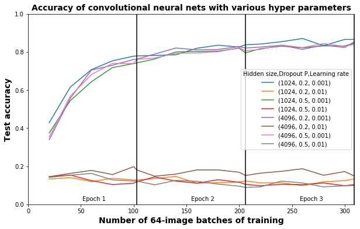

```python
fig = plot_accuracies(test_accuracies)
fig.savefig('Test accuracy vs hyper parameters.png', dpi=300, bbox_inches='tight')
```

[figure not shown]

```python
fig = plot_accuracies(validation_accuracies)
fig.savefig('Validation accuracy vs hyper parameters.png', dpi=300, bbox_inches='tight')
```

#### Interpretation

The above graph shows how the test accuracy evolves as the number steps in the batch gradient descent (with 64 images in each batch) increases for various sets of hyper parameters (size of the hidden layer in the classifier, probability of dropout and learning rate of the optimizer).

Very clearly the learning rate of 0.001 gives better results than the learning rate of 0.01. The four models with a learning rate of 0.001 give similar results. We'll use the one that gave the best results: learning rate of 0.001, 1024 nodes in the hidden layer, 0.2 dropout probability, 3 epochs.

```python
best_model = create_train_return_model(1024, 0.2, 0.001, 3)
best_model
```

```
VGG(
  (features): Sequential(
    (0): Conv2d(3, 64, kernel_size=(3, 3), stride=(1, 1), padding=(1, 1))
    (1): ReLU(inplace)
    (2): MaxPool2d(kernel_size=2, stride=2, padding=0, dilation=1, ceil_mode=False)
    (3): Conv2d(64, 128, kernel_size=(3, 3), stride=(1, 1), padding=(1, 1))
    (4): ReLU(inplace)
    (5): MaxPool2d(kernel_size=2, stride=2, padding=0, dilation=1, ceil_mode=False)
    (6): Conv2d(128, 256, kernel_size=(3, 3), stride=(1, 1), padding=(1, 1))
    (7): ReLU(inplace)
    (8): Conv2d(256, 256, kernel_size=(3, 3), stride=(1, 1), padding=(1, 1))
    (9): ReLU(inplace)
    (10): MaxPool2d(kernel_size=2, stride=2, padding=0, dilation=1, ceil_mode=False)
    (11): Conv2d(256, 512, kernel_size=(3, 3), stride=(1, 1), padding=(1, 1))
    (12): ReLU(inplace)
    (13): Conv2d(512, 512, kernel_size=(3, 3), stride=(1, 1), padding=(1, 1))
    (14): ReLU(inplace)
    (15): MaxPool2d(kernel_size=2, stride=2, padding=0, dilation=1, ceil_mode=False)
    (16): Conv2d(512, 512, kernel_size=(3, 3), stride=(1, 1), padding=(1, 1))
    (17): ReLU(inplace)
    (18): Conv2d(512, 512, kernel_size=(3, 3), stride=(1, 1), padding=(1, 1))
    (19): ReLU(inplace)
    (20): MaxPool2d(kernel_size=2, stride=2, padding=0, dilation=1, ceil_mode=False)
  )
  (classifier): Sequential(
    (fc1): Linear(in_features=25088, out_features=1024, bias=True)
    (ReLU_1): ReLU()
    (Dropout): Dropout(p=0.2)
    (fc2): Linear(in_features=1024, out_features=102, bias=True)
    (LogSoftmax): LogSoftmax()
  )
)
```

## Save the checkpoint

Now that your network is trained, save the model so you can load it later for making predictions. You probably want to save other things such as the mapping of classes to indices which you get from one of the image datasets: `image_datasets['train'].class_to_idx`. You can attach this to the model as an attribute which makes inference easier later on.

`model.class_to_idx = image_datasets['train'].class_to_idx`

Remember that you'll want to completely rebuild the model later so you can use it for inference. Make sure to include any information you need in the checkpoint. If you want to load the model and keep training, you'll want to save the number of epochs as well as the optimizer state, `optimizer.state_dict`. You'll likely want to use this trained model in the next part of the project, so best to save it now.

```python
class_to_idx = image_datasets['train'].class_to_idx
idx_to_class = dict([(class_to_idx[cls], cls) for cls in class_to_idx])
idx_to_name = dict([(idx, cat_to_name[idx_to_class[idx]]) for idx in idx_to_class])
```

```python
# TODO: Save the checkpoint

checkpoint = {
    'hidden_size': 1024,
    'p_dropout': 0.2,
    'learning_rate': 0.001,
    'class_to_idx': class_to_idx,
    'idx_to_class': idx_to_class,
    'idx_to_name': idx_to_name,
    'class_to_name': cat_to_name,
    'state_dict': best_model.state_dict()
}

torch.save(checkpoint, 'checkpoint.pth')
```

## Loading the checkpoint

At this point it's good to write a function that can load a checkpoint and rebuild the model. That way you can come back to this project and keep working on it without having to retrain the network.

```python
# TODO: Write a function that loads a checkpoint and rebuilds the model

def load_checkpoint(filepath):
    checkpoint = torch.load(filepath)
    model = create_model(hidden_size=checkpoint['hidden_size'],
                         p_dropout=checkpoint['p_dropout'])
    model.load_state_dict(checkpoint['state_dict'])
    model.class_to_idx = checkpoint['class_to_idx']
    model.idx_to_class = checkpoint['idx_to_class']
    model.idx_to_name = checkpoint['idx_to_name']
    model.class_to_name = checkpoint['class_to_name']
    return model
```

```python
model = load_checkpoint('checkpoint.pth')
```

# Inference for classification

Now you'll write a function to use a trained network for inference. That is, you'll pass an image into the network and predict the class of the flower in the image. Write a function called `predict` that takes an image and a model, then returns the top $K$ most likely classes along with the probabilities. It should look like

```
probs, classes = predict(image_path, model)
print(probs)
print(classes)
> [ 0.01558163  0.01541934  0.01452626  0.01443549  0.01407339]
> ['70', '3', '45', '62', '55']
```

First you'll need to handle processing the input image such that it can be used in your network.

## Image Preprocessing

You'll want to use `PIL` to load the image ([documentation](https://pillow.readthedocs.io/en/latest/reference/Image.html)). It's best to write a function that preprocesses the image so it can be used as input for the model. This function should process the images in the same manner used for training.

First, resize the images where the shortest side is 256 pixels, keeping the aspect ratio. This can be done with the [`thumbnail`](http://pillow.readthedocs.io/en/3.1.x/reference/Image.html#PIL.Image.Image.thumbnail) or [`resize`](http://pillow.readthedocs.io/en/3.1.x/reference/Image.html#PIL.Image.Image.thumbnail) methods. Then you'll need to crop out the center 224x224 portion of the image.

Color channels of images are typically encoded as integers 0-255, but the model expected floats 0-1. You'll need to convert the values. It's easiest with a Numpy array, which you can get from a PIL image like so `np_image = np.array(pil_image)`.

As before, the network expects the images to be normalized in a specific way. For the means, it's `[0.485, 0.456, 0.406]` and for the standard deviations `[0.229, 0.224, 0.225]`. You'll want to subtract the means from each color channel, then divide by the standard deviation.

And finally, PyTorch expects the color channel to be the first dimension but it's the third dimension in the PIL image and Numpy array. You can reorder dimensions using [`ndarray.transpose`](https://docs.scipy.org/doc/numpy-1.13.0/reference/generated/numpy.ndarray.transpose.html). The color channel needs to be first and retain the order of the other two dimensions.

```python
image_path = 'flowers/test/10/image_07090.jpg'
pil_image = PIL.Image.open(image_path)
```

```python
def resize(pil_image, size=256):
    ''' Returns a scaled version of the input image such that the length
        of the shortest side equals the `size` parameter, preserving the
        aspect ratio of the image.
    '''
    initial_size = np.array(pil_image.size)
    shortest_side = initial_size.min()
    resize_ratio = size/shortest_side
    new_size = (resize_ratio * initial_size).round().astype(int)
    return pil_image.resize(new_size)
```

```python
def center_crop(pil_image, size=224):
    ''' Returns a square and centered crop of the input
        image of dimensions size * size.
    '''
    w, h= pil_image.size
    l = int((w - size) / 2)
    r = l + size
    t = int((h - size) / 2)
    b = t + size
    return pil_image.crop((l, t, r, b))
```

```python
def normalize_tranpose(pil_image, means=[0.485, 0.456, 0.406], std=[0.229, 0.224, 0.225]):
    ''' Normalizes the input pil_image by first dividing by 255 to bring
        the values between 0 and 1, then subtracts `means` and divides by `std`.
        Return the corresponding np_image transposed in a way that the color channel is first.
    '''
    means=np.array(means)
    std=np.array(std)
    np_image = np.array(pil_image)
    scaled_image = ((np_image/255) - means)/std
    return scaled_image.transpose(2, 0, 1)
```

```python
def process_image(image):
    ''' Scales, crops, and normalizes a PIL image for a PyTorch model,
        returns an Numpy array
    '''
    # TODO: Process a PIL image for use in a PyTorch model
    return normalize_tranpose(center_crop(resize(image)))
```

To check your work, the function below converts a PyTorch tensor and displays it in the notebook. If your `process_image` function works, running the output through this function should return the original image (except for the cropped out portions).

```python
def imshow(image, ax=None, title=None):
    if ax is None:
        fig, ax = plt.subplots()

    # PyTorch tensors assume the color channel is the first dimension
    # but matplotlib assumes is the third dimension
    image = image.transpose((1, 2, 0))

    # Undo preprocessing
    mean = np.array([0.485, 0.456, 0.406])
    std = np.array([0.229, 0.224, 0.225])
    image = std * image + mean

    # Image needs to be clipped between 0 and 1 or it looks like noise when displayed
    image = np.clip(image, 0, 1)

    ax.imshow(image)

    return ax
```

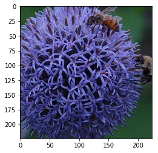

```python
imshow(process_image(pil_image))
```

## Class Prediction

Once you can get images in the correct format, it's time to write a function for making predictions with your model. A common practice is to predict the top 5 or so (usually called top-$K$) most probable classes. You'll want to calculate the class probabilities then find the $K$ largest values.

To get the top $K$ largest values in a tensor use [`x.topk(k)`](http://pytorch.org/docs/master/torch.html#torch.topk). This method returns both the highest `k` probabilities and the indices of those probabilities corresponding to the classes. You need to convert from these indices to the actual class labels using `class_to_idx` which hopefully you added to the model or from an `ImageFolder` you used to load the data (see here). Make sure to invert the dictionary so you get a mapping from index to class as well.

Again, this method should take a path to an image and a model checkpoint, then return the probabilities and classes.

```
probs, classes = predict(image_path, model)
print(probs)
print(classes)
> [ 0.01558163  0.01541934  0.01452626  0.01443549  0.01407339]
> ['70', '3', '45', '62', '55']
```

```python
image_path = "flowers/test/10/image_07090.jpg"
```

```python
def predict(image_path, model, topk=5):
    ''' Predict the class (or classes) of an image using a trained deep learning model.
    '''
    model = load_checkpoint(model)
    model.to('cuda')
    model.eval()

    pil_image = PIL.Image.open(image_path)
    processed_image = process_image(pil_image)
    tensor = torch.from_numpy(processed_image)
    tensor = tensor.float()
    tensor.resize_(1, 3, 224, 224)
    tensor = tensor.to('cuda')

    with torch.no_grad():
        probs, classes = torch.exp(model(tensor)).topk(topk)

    probs, classes = probs.to('cpu'), classes.to('cpu')
    probs, classes = list(probs.numpy()[0]), list(classes.numpy()[0])

    return probs, [model.idx_to_class[idx] for idx in classes]
    # TODO: Implement the code to predict the class from an image file
```

```python
probs, classes = predict(image_path, 'checkpoint.pth')
```

```python
probs
```

```
[0.99894387, 0.00052801555, 0.0001387907, 0.00013373465, 9.6880794e-05]
```

```python
classes
```

```
['10', '29', '92', '77', '13']
```

## Sanity Checking

Now that you can use a trained model for predictions, check to make sure it makes sense. Even if the testing accuracy is high, it's always good to check that there aren't obvious bugs. Use `matplotlib` to plot the probabilities for the top 5 classes as a bar graph, along with the input image. It should look like this:

[figure not shown]

You can convert from the class integer encoding to actual flower names with the `cat_to_name.json` file (should have been loaded earlier in the notebook). To show a PyTorch tensor as an image, use the `imshow` function defined above.

```python
# TODO: Display an image along with the top 5 classes

def sanity_check(image_path, checkpoint='checkpoint.pth'):

    probs, classes = predict(image_path, checkpoint)

    model = load_checkpoint(checkpoint)
    names = [model.class_to_name[cls] for cls in classes]

    # Find correct image class from the name of the folder containing the image
    regex = re.compile(r'/(\d+)/')
    img_class, = regex.search(image_path).groups()
    flower_name = model.class_to_name[img_class]

    # Create plot
    fig, axs = plt.subplots(2, 1, figsize=(5, 8))

    ax = axs[0]
    ax.imshow(PIL.Image.open(image_path))
    ax.xaxis.set_visible(False)
    ax.yaxis.set_visible(False)
    ax.set_title(flower_name)

    ax = axs[1]
    ax.barh(names, probs)
```

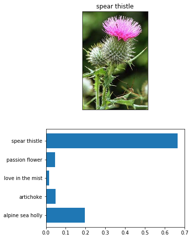

```python
image_path = "flowers/test/14/image_06091.jpg"
sanity_check(image_path)
```

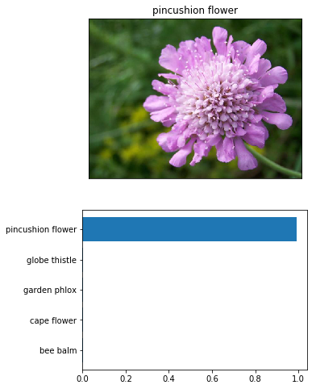

```python
image_path = "flowers/valid/22/image_05368.jpg"
sanity_check(image_path)
```

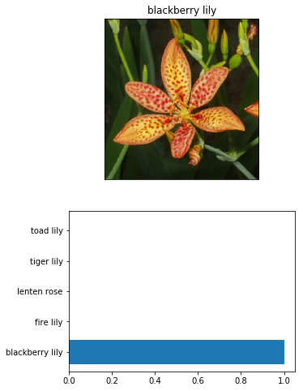

```python
image_path = "flowers/valid/102/image_08040.jpg"
sanity_check(image_path)
```